# People’s Bank of China current statistical values

Major series from every current official statistical table

23 July 2026

The Chinese statistical archive supplies the complete current-year collection. The dashboard selects the latest official workbook for each distinct statistical table, reads it through `readPBOC`, and charts its major reported series. Each release has its own tab inside the corresponding statistical section.

26Current statistical releases

3,095Normalised values

5Statistical sections

26Releases with value charts

Snapshot refreshed at 2026-07-23 19:21 AEST. The workbook publication dates span 30 April 2026 through 22 July 2026.

## Coverage overview

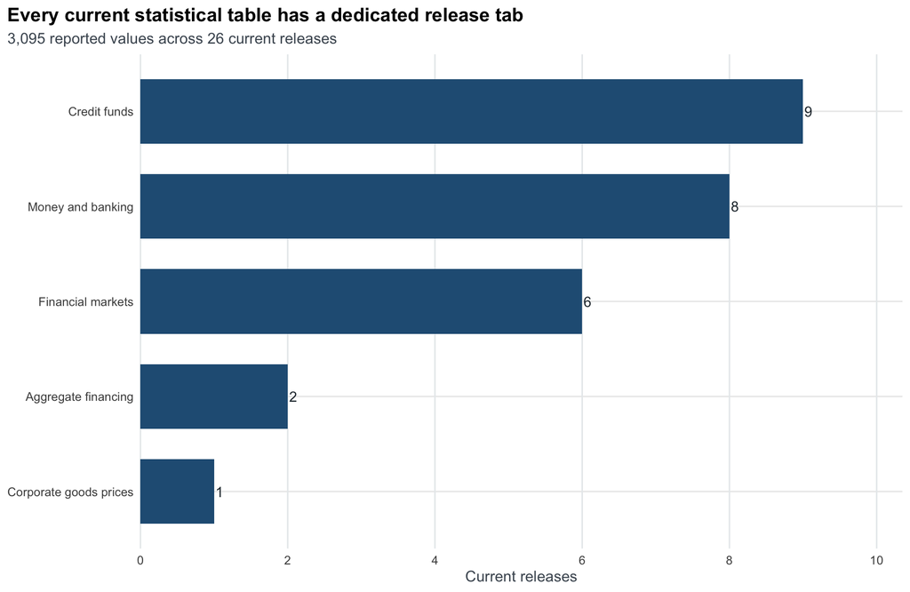

```r
coverage <- current_catalog |>
  count(section_id, name = "releases") |>
  mutate(section = unname(section_labels[section_id]))

ggplot(
  coverage,
  aes(x = reorder(section, releases), y = releases)
) +
  geom_col(fill = "#265D84", width = 0.68) +
  geom_text(
    aes(label = releases),
    hjust = -0.18,
    colour = "#27343D",
    size = 4
  ) +
  coord_flip(clip = "off") +
  scale_y_continuous(
    breaks = pretty_breaks(),
    expand = expansion(mult = c(0, 0.15))
  ) +
  labs(
    title = "Every current statistical table has a dedicated release tab",
    subtitle = paste(
      comma(nrow(current_values)),
      "reported values across",
      nrow(current_catalog),
      "current releases"
    ),
    x = NULL,
    y = "Current releases"
  ) +
  theme_pboc_values()
```

## Aggregate financing

### AFRE flow

社会融资规模增量统计表

**Published:** 15 July 2026 **Values:** 66 **Series:** 11  
[Open the official PBOC workbook](https://www.pbc.gov.cn/diaochatongjisi/attachDir/2026/07/2026071516450066562.xlsx)

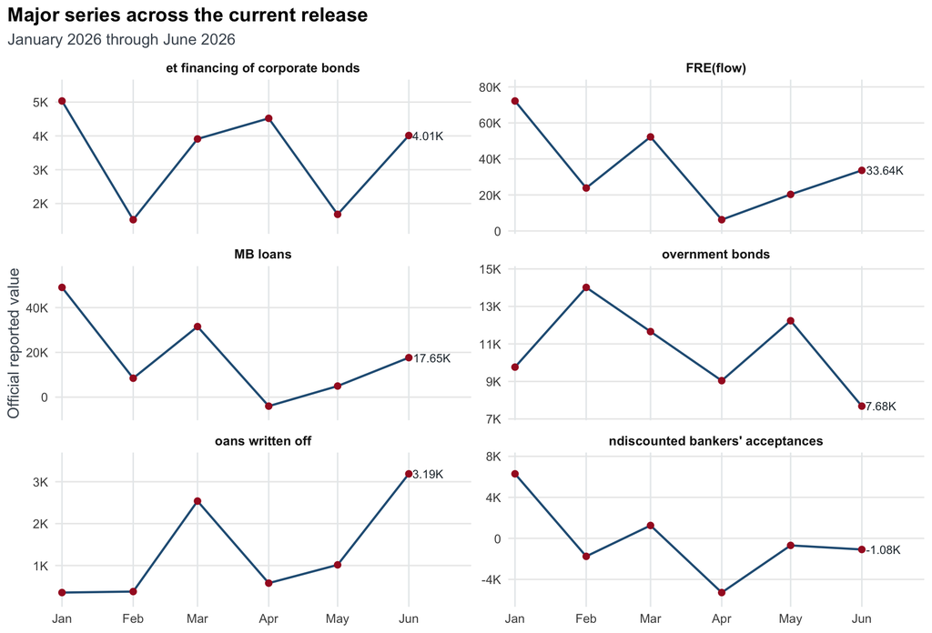

Latest values for the selected major series

| Series | Period | Value |
| --- | --- | --- |
| FRE(flow) | 2026-06 | 33,645.00 |
| MB loans | 2026-06 | 17,650.00 |
| et financing of corporate bonds | 2026-06 | 4,012.00 |
| ndiscounted bankers’ acceptances | 2026-06 | -1,084.00 |
| oans written off | 2026-06 | 3,188.00 |
| overnment bonds | 2026-06 | 7,683.00 |

### AFRE stock

社会融资规模存量统计表

**Published:** 15 July 2026 **Values:** 66 **Series:** 11  
[Open the official PBOC workbook](https://www.pbc.gov.cn/diaochatongjisi/attachDir/2026/07/2026071516452812082.xlsx)

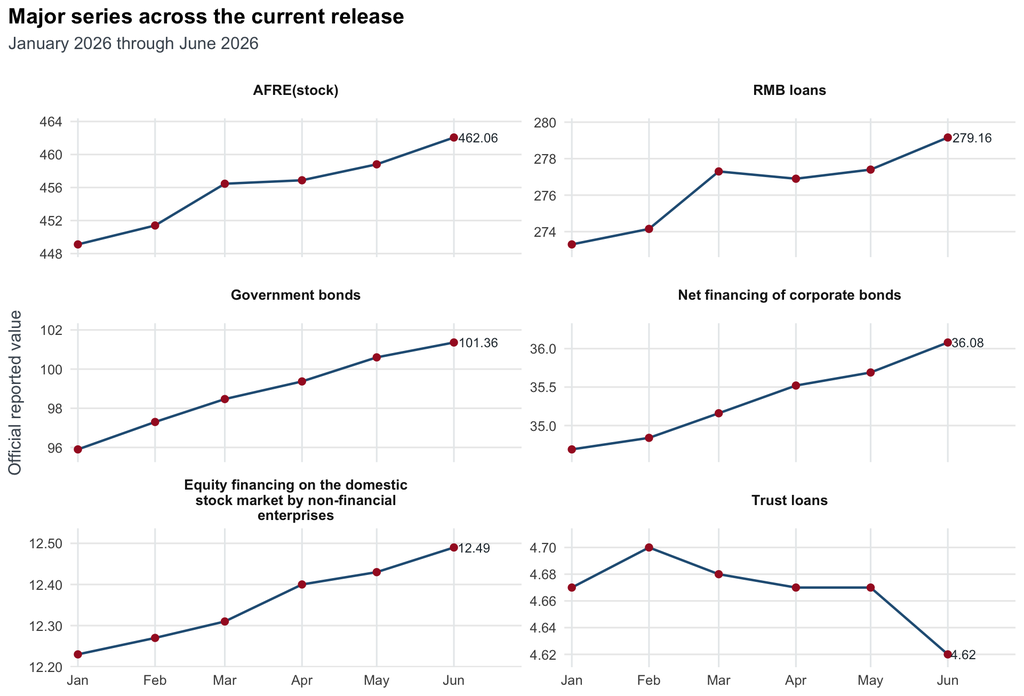

Latest values for the selected major series

| Series | Period | Value |
| --- | --- | --- |
| AFRE(stock) | 2026-06 | 462.06 |
| Equity financing on the domestic stock market by non-financial enterprises | 2026-06 | 12.49 |
| Government bonds | 2026-06 | 101.36 |
| Net financing of corporate bonds | 2026-06 | 36.08 |
| RMB loans | 2026-06 | 279.16 |
| Trust loans | 2026-06 | 4.62 |

## Corporate goods prices

### Corporate goods prices

企业商品价格指数

**Published:** 15 July 2026 **Values:** 24 **Series:** 4  
[Open the official PBOC workbook](https://www.pbc.gov.cn/diaochatongjisi/attachDir/2026/07/2026071516553174269.xlsx)

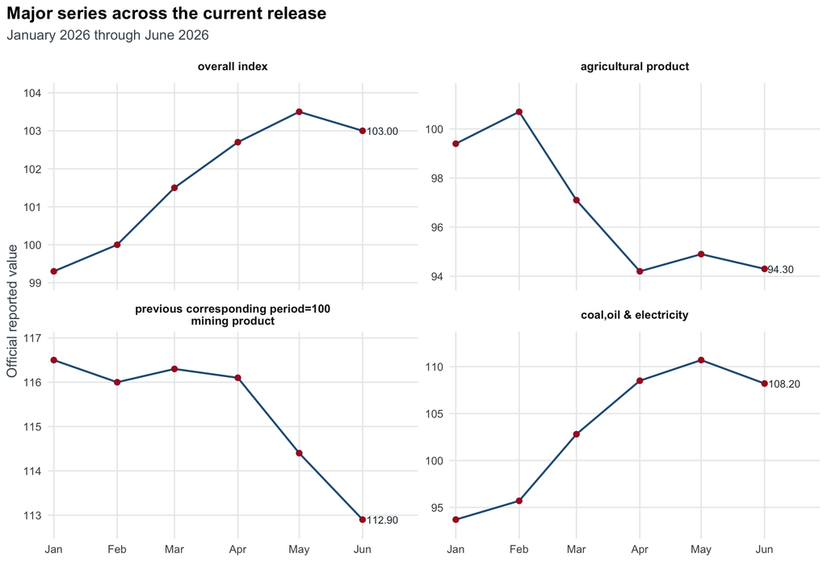

Latest values for the selected major series

| Series | Period | Value |
| --- | --- | --- |
| agricultural product | 2026-06 | 94.30 |
| coal,oil & electricity | 2026-06 | 108.20 |
| overall index | 2026-06 | 103.00 |
| previous corresponding period=100 mining product | 2026-06 | 112.90 |

## Credit funds

### 4 largest banks (RMB)

中资全国性四家大型银行人民币信贷收支表

**Published:** 15 July 2026 **Values:** 204 **Series:** 31  
[Open the official PBOC workbook](https://www.pbc.gov.cn/diaochatongjisi/attachDir/2026/07/2026071516535144806.xlsx)

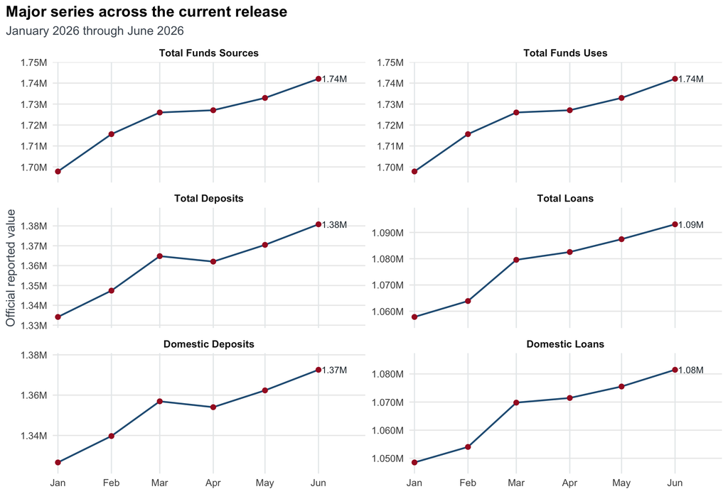

Latest values for the selected major series

| Series | Period | Value |
| --- | --- | --- |
| Domestic Deposits | 2026-06 | 1,372,578.09 |
| Domestic Loans | 2026-06 | 1,081,473.06 |
| Total Deposits | 2026-06 | 1,380,809.97 |
| Total Funds Sources | 2026-06 | 1,742,066.51 |
| Total Funds Uses | 2026-06 | 1,742,066.51 |
| Total Loans | 2026-06 | 1,093,105.93 |

### Depository institutions (RMB)

存款类金融机构人民币信贷收支表

**Published:** 15 July 2026 **Values:** 240 **Series:** 36  
[Open the official PBOC workbook](https://www.pbc.gov.cn/diaochatongjisi/attachDir/2026/07/2026071516524787642.xlsx)

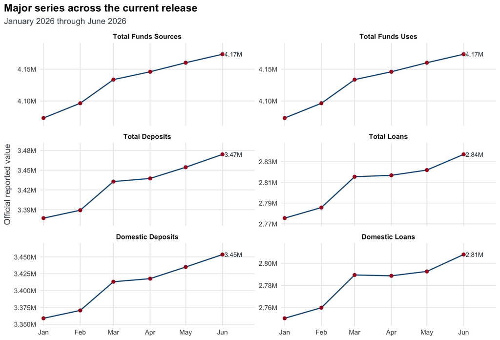

Latest values for the selected major series

| Series | Period | Value |
| --- | --- | --- |
| Domestic Deposits | 2026-06 | 3,453,491.05 |
| Domestic Loans | 2026-06 | 2,807,945.53 |
| Total Deposits | 2026-06 | 3,474,020.04 |
| Total Funds Sources | 2026-06 | 4,173,581.01 |
| Total Funds Uses | 2026-06 | 4,173,581.01 |
| Total Loans | 2026-06 | 2,836,959.77 |

### Depository institutions (in Foreign Currency)

存款类金融机构外汇信贷收支表

**Published:** 15 July 2026 **Values:** 228 **Series:** 35  
[Open the official PBOC workbook](https://www.pbc.gov.cn/diaochatongjisi/attachDir/2026/07/2026071516512286976.xlsx)

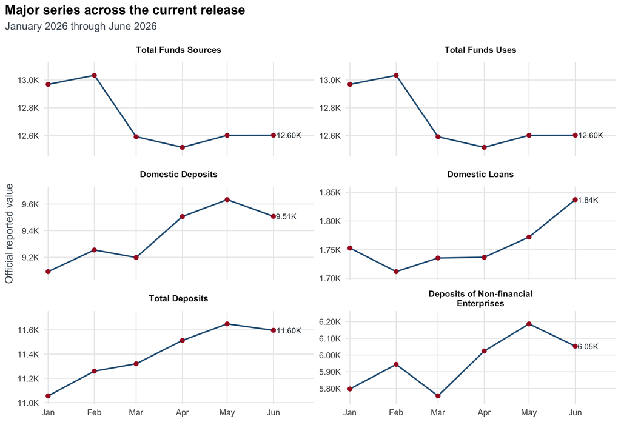

Latest values for the selected major series

| Series | Period | Value |
| --- | --- | --- |
| Deposits of Non-financial Enterprises | 2026-06 | 6,053.28 |
| Domestic Deposits | 2026-06 | 9,507.78 |
| Domestic Loans | 2026-06 | 1,837.20 |
| Total Deposits | 2026-06 | 11,596.20 |
| Total Funds Sources | 2026-06 | 12,601.95 |
| Total Funds Uses | 2026-06 | 12,601.95 |

### Depository institutions (in RMB and Foreign Currency)

存款类金融机构本外币信贷收支表

**Published:** 15 July 2026 **Values:** 222 **Series:** 33  
[Open the official PBOC workbook](https://www.pbc.gov.cn/diaochatongjisi/attachDir/2026/07/2026071516501831576.xlsx)

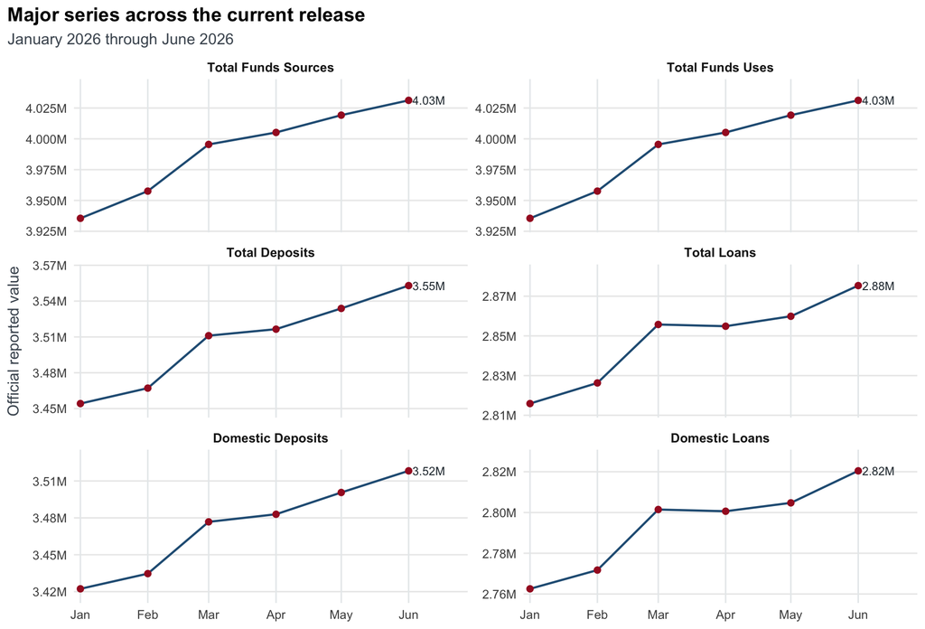

Latest values for the selected major series

| Series | Period | Value |
| --- | --- | --- |
| Domestic Deposits | 2026-06 | 3,518,247.56 |
| Domestic Loans | 2026-06 | 2,820,458.54 |
| Total Deposits | 2026-06 | 3,553,000.59 |
| Total Funds Sources | 2026-06 | 4,031,235.58 |
| Total Funds Uses | 2026-06 | 4,031,235.58 |
| Total Loans | 2026-06 | 2,875,347.53 |

### Financial institutions (RMB)

金融机构人民币信贷收支表

**Published:** 15 July 2026 **Values:** 240 **Series:** 36  
[Open the official PBOC workbook](https://www.pbc.gov.cn/diaochatongjisi/attachDir/2026/07/2026071516521532997.xlsx)

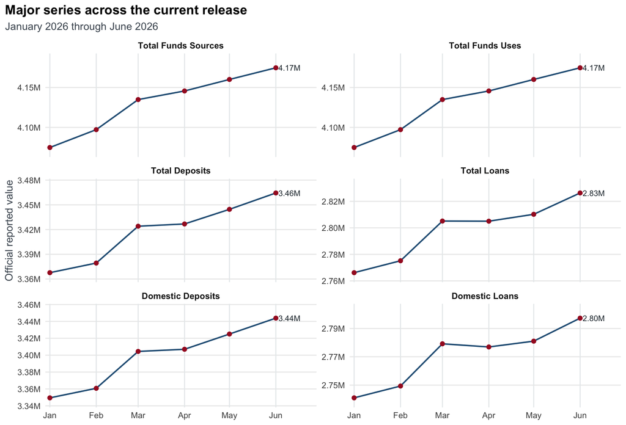

Latest values for the selected major series

| Series | Period | Value |
| --- | --- | --- |
| Domestic Deposits | 2026-06 | 3,443,879.37 |
| Domestic Loans | 2026-06 | 2,797,292.43 |
| Total Deposits | 2026-06 | 3,464,408.35 |
| Total Funds Sources | 2026-06 | 4,174,713.96 |
| Total Funds Uses | 2026-06 | 4,174,713.96 |
| Total Loans | 2026-06 | 2,826,308.30 |

### Financial institutions (in Foreign Currency)

金融机构外汇信贷收支表

**Published:** 15 July 2026 **Values:** 234 **Series:** 36  
[Open the official PBOC workbook](https://www.pbc.gov.cn/diaochatongjisi/attachDir/2026/07/2026071516505149479.xlsx)

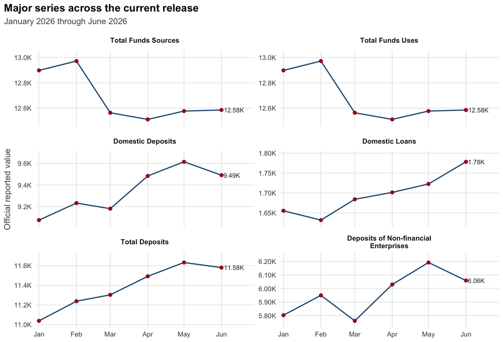

Latest values for the selected major series

| Series | Period | Value |
| --- | --- | --- |
| Deposits of Non-financial Enterprises | 2026-06 | 6,059.18 |
| Domestic Deposits | 2026-06 | 9,490.93 |
| Domestic Loans | 2026-06 | 1,778.37 |
| Total Deposits | 2026-06 | 11,579.89 |
| Total Funds Sources | 2026-06 | 12,584.49 |
| Total Funds Uses | 2026-06 | 12,584.49 |

### Financial institutions (in RMB and Foreign Currency)

金融机构本外币信贷收支表

**Published:** 15 July 2026 **Values:** 222 **Series:** 33  
[Open the official PBOC workbook](https://www.pbc.gov.cn/diaochatongjisi/attachDir/2026/07/2026071516495043571.xlsx)

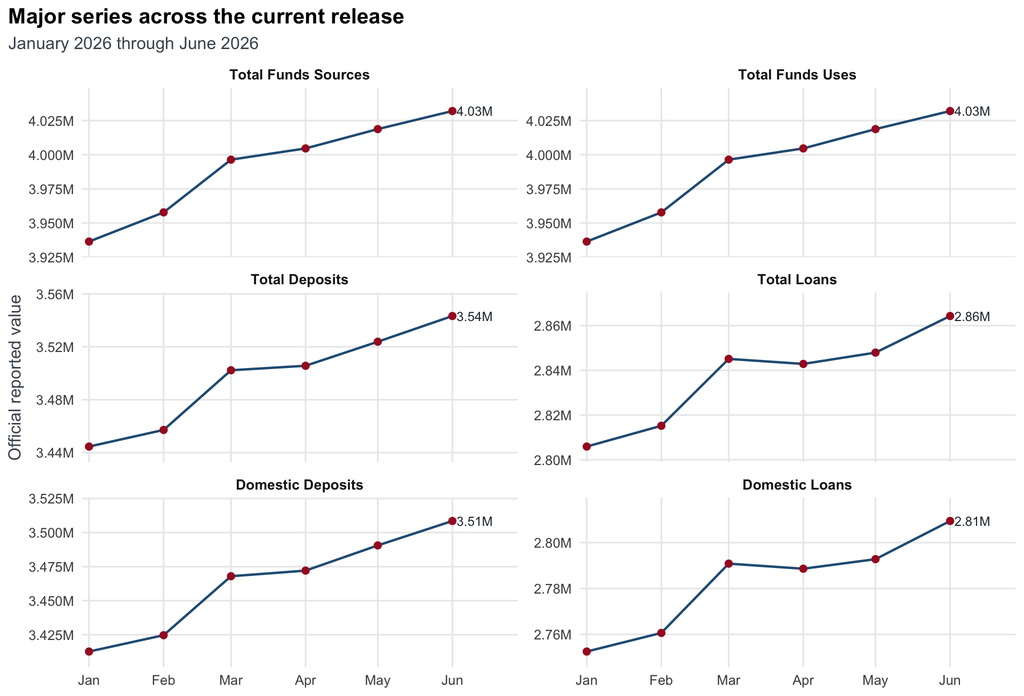

Latest values for the selected major series

| Series | Period | Value |
| --- | --- | --- |
| Domestic Deposits | 2026-06 | 3,508,521.17 |
| Domestic Loans | 2026-06 | 2,809,404.74 |
| Total Deposits | 2026-06 | 3,543,277.82 |
| Total Funds Sources | 2026-06 | 4,032,033.43 |
| Total Funds Uses | 2026-06 | 4,032,033.43 |
| Total Loans | 2026-06 | 2,864,295.37 |

### large-sized banks (RMB)

中资全国性大型银行人民币信贷收支表

**Published:** 15 July 2026 **Values:** 204 **Series:** 31  
[Open the official PBOC workbook](https://www.pbc.gov.cn/diaochatongjisi/attachDir/2026/07/2026071516532267859.xlsx)

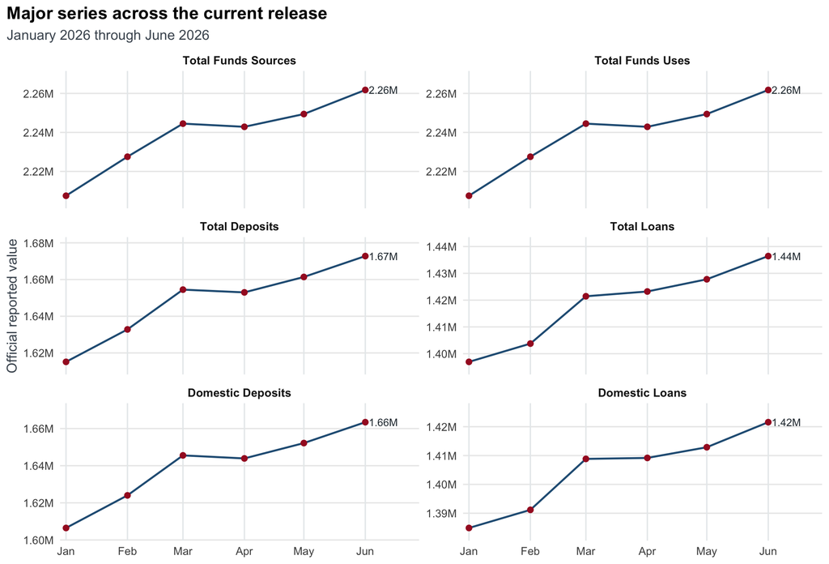

Latest values for the selected major series

| Series | Period | Value |
| --- | --- | --- |
| Domestic Deposits | 2026-06 | 1,663,435.88 |
| Domestic Loans | 2026-06 | 1,421,575.56 |
| Total Deposits | 2026-06 | 1,672,794.17 |
| Total Funds Sources | 2026-06 | 2,261,769.66 |
| Total Funds Uses | 2026-06 | 2,261,769.66 |
| Total Loans | 2026-06 | 1,436,442.41 |

### medium & small-sized banks (RMB)

中资全国性中小型银行人民币信贷收支表

**Published:** 15 July 2026 **Values:** 204 **Series:** 32  
[Open the official PBOC workbook](https://www.pbc.gov.cn/diaochatongjisi/attachDir/2026/07/2026071516543577658.xlsx)

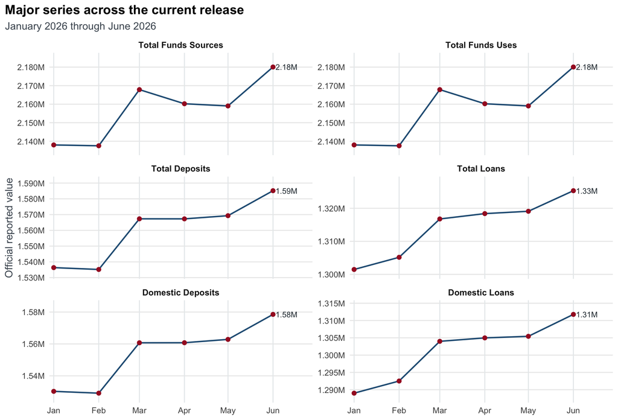

Latest values for the selected major series

| Series | Period | Value |
| --- | --- | --- |
| Domestic Deposits | 2026-06 | 1,578,531.72 |
| Domestic Loans | 2026-06 | 1,311,773.23 |
| Total Deposits | 2026-06 | 1,585,165.11 |
| Total Funds Sources | 2026-06 | 2,180,056.03 |
| Total Funds Uses | 2026-06 | 2,180,056.03 |
| Total Loans | 2026-06 | 1,325,320.92 |

## Financial markets

### Government bond yields

中债国债收益统计表

**Published:** 30 June 2026 **Values:** 35 **Series:** 7  
[Open the official PBOC workbook](https://www.pbc.gov.cn/diaochatongjisi/attachDir/2026/06/2026063016300591210.xlsx)

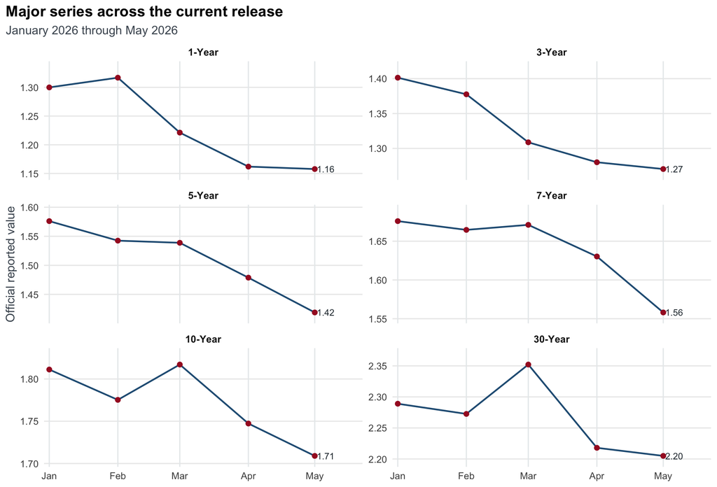

Latest values for the selected major series

| Series | Period | Value |
| --- | --- | --- |
| 1-Year | 2026-05 | 1.16 |
| 10-Year | 2026-05 | 1.71 |
| 3-Year | 2026-05 | 1.27 |
| 30-Year | 2026-05 | 2.20 |
| 5-Year | 2026-05 | 1.42 |
| 7-Year | 2026-05 | 1.56 |

### Domestic debt securities

国内各类债券统计表

**Published:** 22 July 2026 **Values:** 60 **Series:** 7  
[Open the official PBOC workbook](https://www.pbc.gov.cn/diaochatongjisi/attachDir/2026/07/2026072210004176013.xlsx)

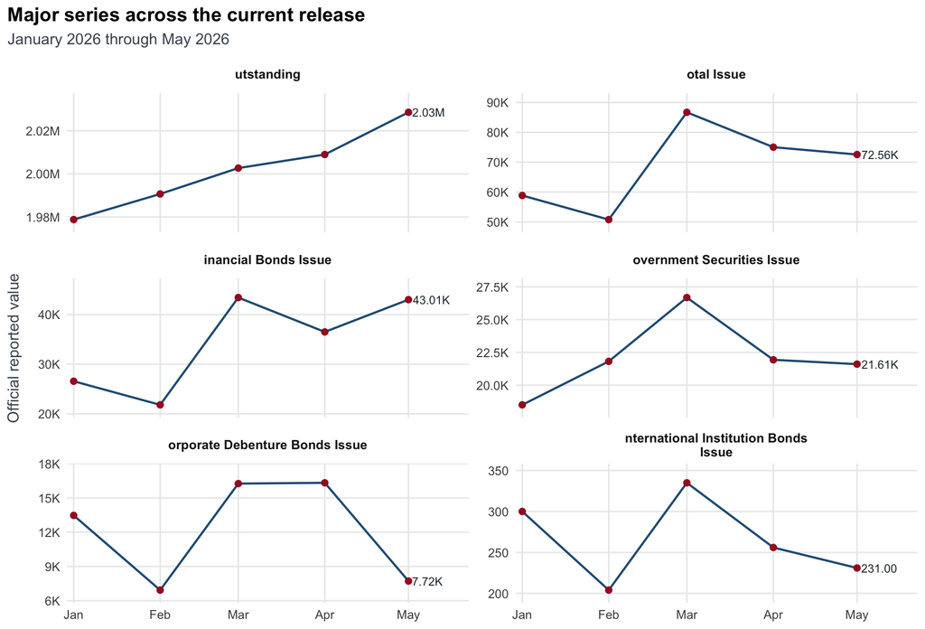

Latest values for the selected major series

| Series | Period | Value |
| --- | --- | --- |
| inancial Bonds Issue | 2026-05 | 43,010.00 |
| nternational Institution Bonds Issue | 2026-05 | 231.00 |
| orporate Debenture Bonds Issue | 2026-05 | 7,717.00 |
| otal Issue | 2026-05 | 72,564.00 |
| overnment Securities Issue | 2026-05 | 21,606.00 |
| utstanding | 2026-05 | 2,028,570.00 |

### Interbank lending

全国银行间同业拆借交易统计表

**Published:** 30 June 2026 **Values:** 120 **Series:** 13  
[Open the official PBOC workbook](https://www.pbc.gov.cn/diaochatongjisi/attachDir/2026/06/2026063016303448227.xlsx)

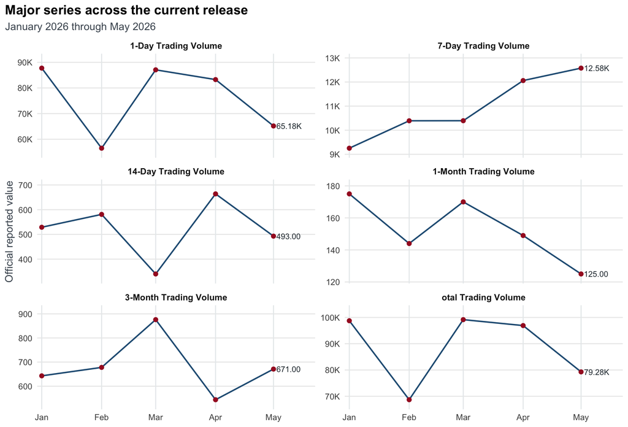

Latest values for the selected major series

| Series | Period | Value |
| --- | --- | --- |
| 1-Day Trading Volume | 2026-05 | 65,181.00 |
| 1-Month Trading Volume | 2026-05 | 125.00 |
| 14-Day Trading Volume | 2026-05 | 493.00 |
| 3-Month Trading Volume | 2026-05 | 671.00 |
| 7-Day Trading Volume | 2026-05 | 12,577.00 |
| otal Trading Volume | 2026-05 | 79,284.00 |

### Pledged repo

全国银行间质押式回购交易统计表

**Published:** 30 June 2026 **Values:** 110 **Series:** 13  
[Open the official PBOC workbook](https://www.pbc.gov.cn/diaochatongjisi/attachDir/2026/06/2026063016305784166.xlsx)

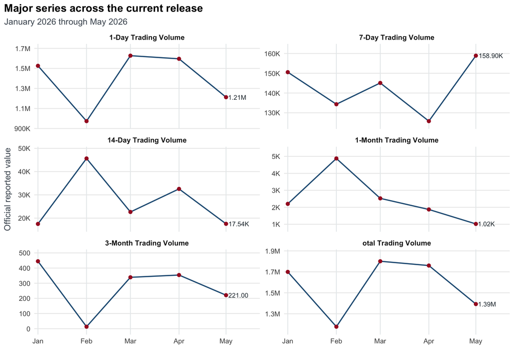

Latest values for the selected major series

| Series | Period | Value |
| --- | --- | --- |
| 1-Day Trading Volume | 2026-05 | 1,212,722.00 |
| 1-Month Trading Volume | 2026-05 | 1,022.00 |
| 14-Day Trading Volume | 2026-05 | 17,541.00 |
| 3-Month Trading Volume | 2026-05 | 221.00 |
| 7-Day Trading Volume | 2026-05 | 158,900.00 |
| otal Trading Volume | 2026-05 | 1,392,616.00 |

### Shibor

Shibor统计表

**Published:** 30 June 2026 **Values:** 40 **Series:** 8  
[Open the official PBOC workbook](https://www.pbc.gov.cn/diaochatongjisi/attachDir/2026/06/2026063016312474941.xlsx)

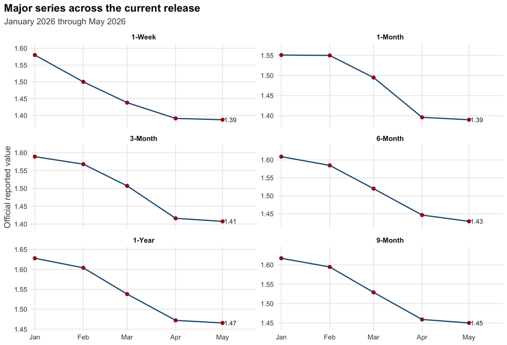

Latest values for the selected major series

| Series | Period | Value |
| --- | --- | --- |
| 1-Month | 2026-05 | 1.39 |
| 1-Week | 2026-05 | 1.39 |
| 1-Year | 2026-05 | 1.47 |
| 3-Month | 2026-05 | 1.41 |
| 6-Month | 2026-05 | 1.43 |
| 9-Month | 2026-05 | 1.45 |

### Stock market

股票市场统计表

**Published:** 30 June 2026 **Values:** 40 **Series:** 8  
[Open the official PBOC workbook](https://www.pbc.gov.cn/diaochatongjisi/attachDir/2026/06/2026063016285368114.xlsx)

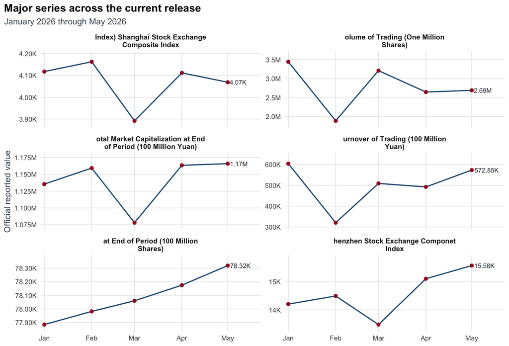

Latest values for the selected major series

| Series | Period | Value |
| --- | --- | --- |
| Index) Shanghai Stock Exchange Composite Index | 2026-05 | 4,069.00 |
| at End of Period (100 Million Shares) | 2026-05 | 78,319.00 |
| henzhen Stock Exchange Componet Index | 2026-05 | 15,575.00 |
| olume of Trading (One Million Shares) | 2026-05 | 2,691,577.00 |
| otal Market Capitalization at End of Period (100 Million Yuan) | 2026-05 | 1,165,844.00 |
| urnover of Trading (100 Million Yuan) | 2026-05 | 572,848.00 |

## Money and banking

### Monetary authority

货币当局资产负债表

**Published:** 15 July 2026 **Values:** 132 **Series:** 22  
[Open the official PBOC workbook](https://www.pbc.gov.cn/diaochatongjisi/attachDir/2026/07/2026071516462779749.xlsx)

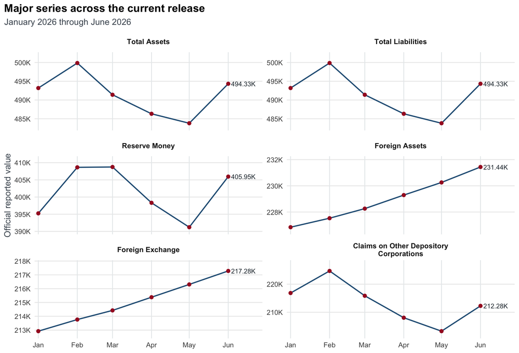

Latest values for the selected major series

| Series | Period | Value |
| --- | --- | --- |
| Claims on Other Depository Corporations | 2026-06 | 212,276.16 |
| Foreign Assets | 2026-06 | 231,436.69 |
| Foreign Exchange | 2026-06 | 217,282.58 |
| Reserve Money | 2026-06 | 405,945.01 |
| Total Liabilities | 2026-06 | 494,334.98 |
| Total Assets | 2026-06 | 494,334.98 |

### Other depository corporations

其他存款性公司资产负债表

**Published:** 15 July 2026 **Values:** 186 **Series:** 30  
[Open the official PBOC workbook](https://www.pbc.gov.cn/diaochatongjisi/attachDir/2026/07/2026071516474787555.xlsx)

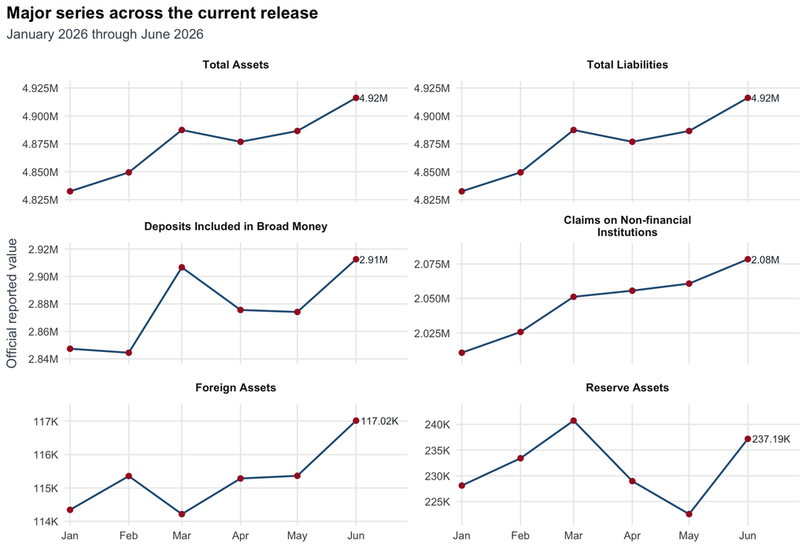

Latest values for the selected major series

| Series | Period | Value |
| --- | --- | --- |
| Claims on Non-financial Institutions | 2026-06 | 2,078,421.85 |
| Deposits Included in Broad Money | 2026-06 | 2,912,535.88 |
| Foreign Assets | 2026-06 | 117,016.62 |
| Reserve Assets | 2026-06 | 237,190.97 |
| Total Liabilities | 2026-06 | 4,916,216.28 |
| Total Assets | 2026-06 | 4,916,216.28 |

### Depository corporations survey

存款性公司概览

**Published:** 15 July 2026 **Values:** 102 **Series:** 17  
[Open the official PBOC workbook](https://www.pbc.gov.cn/diaochatongjisi/attachDir/2026/07/2026071516471484414.xlsx)

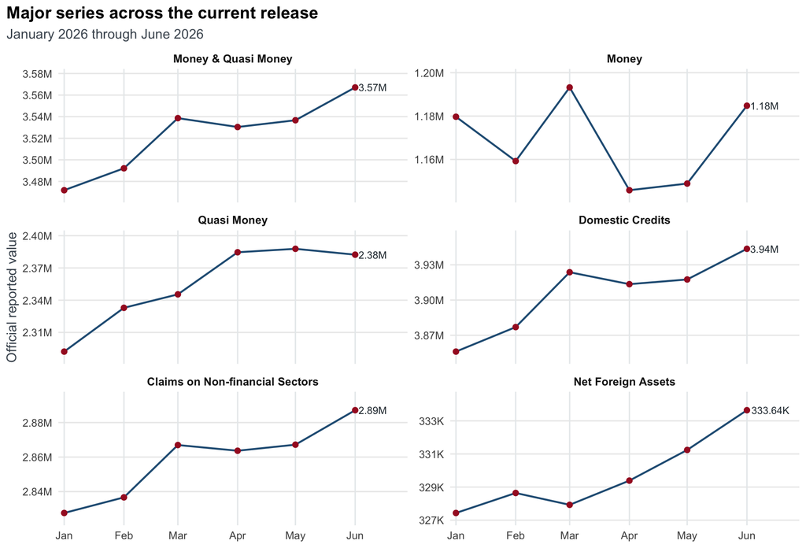

Latest values for the selected major series

| Series | Period | Value |
| --- | --- | --- |
| Claims on Non-financial Sectors | 2026-06 | 2,887,139.74 |
| Domestic Credits | 2026-06 | 3,943,643.66 |
| Money | 2026-06 | 1,184,775.53 |
| Money & Quasi Money | 2026-06 | 3,567,108.43 |
| Net Foreign Assets | 2026-06 | 333,642.48 |
| Quasi Money | 2026-06 | 2,382,332.90 |

### Overseas holdings

境外机构和个人持有境内人民币金融资产情况

**Published:** 30 April 2026 **Values:** 12 **Series:** 4  
[Open the official PBOC workbook](https://www.pbc.gov.cn/diaochatongjisi/attachDir/2026/04/2026043016405817661.xlsx)

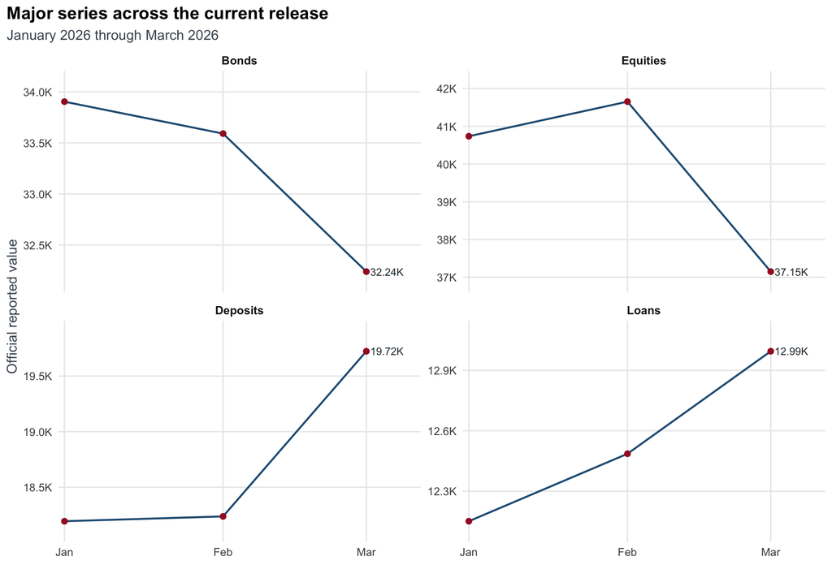

Latest values for the selected major series

| Series | Period | Value |
| --- | --- | --- |
| Bonds | 2026-03 | 32,239.74 |
| Deposits | 2026-03 | 19,723.33 |
| Equities | 2026-03 | 37,149.80 |
| Loans | 2026-03 | 12,994.72 |

### Exchange rates

汇率报表

**Published:** 15 July 2026 **Values:** 18 **Series:** 3  
[Open the official PBOC workbook](https://www.pbc.gov.cn/diaochatongjisi/attachDir/2026/07/2026071516484381222.xlsx)

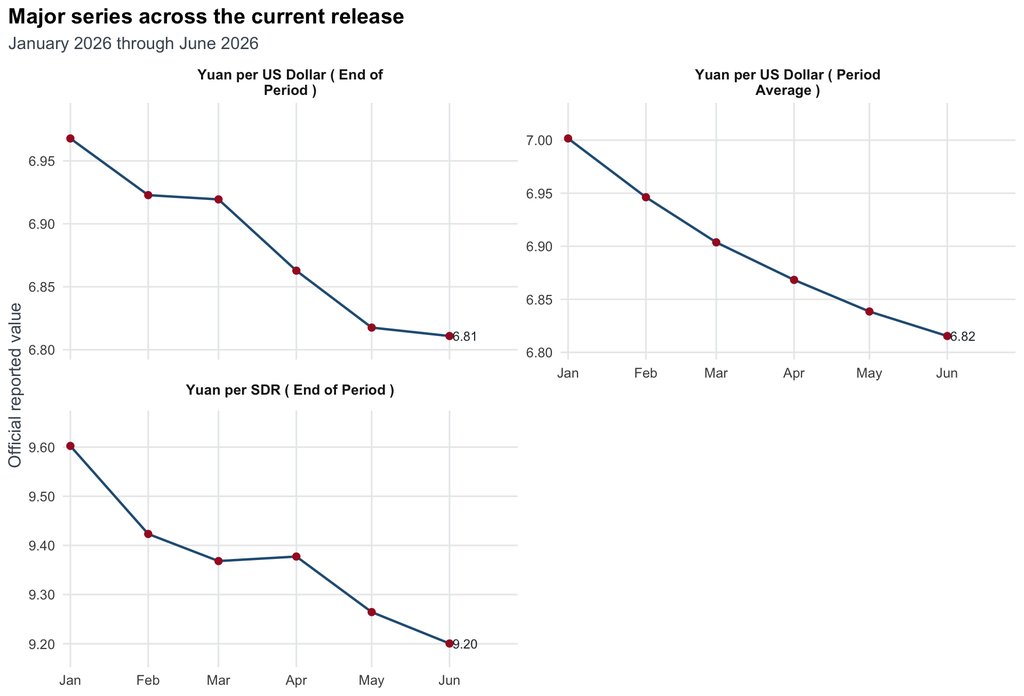

Latest values for the selected major series

| Series | Period | Value |
| --- | --- | --- |
| Yuan per SDR ( End of Period ) | 2026-06 | 9.20 |
| Yuan per US Dollar ( End of Period ) | 2026-06 | 6.81 |
| Yuan per US Dollar ( Period Average ) | 2026-06 | 6.82 |

### Money supply

货币供应量

**Published:** 15 July 2026 **Values:** 18 **Series:** 3  
[Open the official PBOC workbook](https://www.pbc.gov.cn/diaochatongjisi/attachDir/2026/07/2026071516481518348.xlsx)

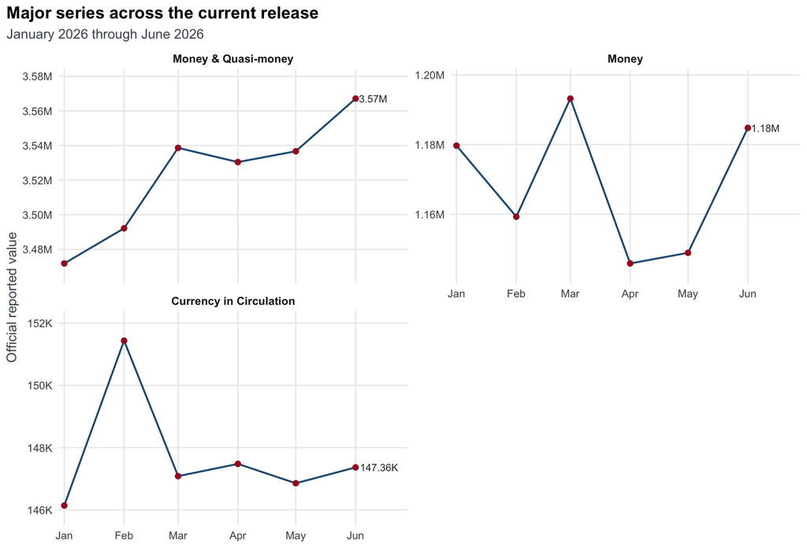

Latest values for the selected major series

| Series | Period | Value |
| --- | --- | --- |
| Currency in Circulation | 2026-06 | 147,364.79 |
| Money | 2026-06 | 1,184,775.53 |
| Money & Quasi-money | 2026-06 | 3,567,108.43 |

### Official reserves

官方储备资产

**Published:** 07 July 2026 **Values:** 36 **Series:** 6  
[Open the official PBOC workbook](https://www.pbc.gov.cn/diaochatongjisi/attachDir/2026/07/2026070716051681267.xlsx)

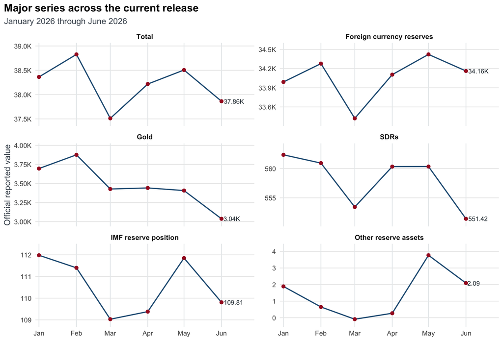

Latest values for the selected major series

| Series | Period | Value |
| --- | --- | --- |
| Foreign currency reserves | 2026-06 | 34,162.62 |
| Gold | 2026-06 | 3,037.24 |
| IMF reserve position | 2026-06 | 109.81 |
| Other reserve assets | 2026-06 | 2.09 |
| SDRs | 2026-06 | 551.42 |
| Total | 2026-06 | 37,863.18 |

### International reserves template

国际储备与外币流动性数据模板

**Published:** 30 June 2026 **Values:** 32 **Series:** 31  
[Open the official PBOC workbook](https://www.pbc.gov.cn/diaochatongjisi/attachDir/2026/06/2026063015594425261.xls)

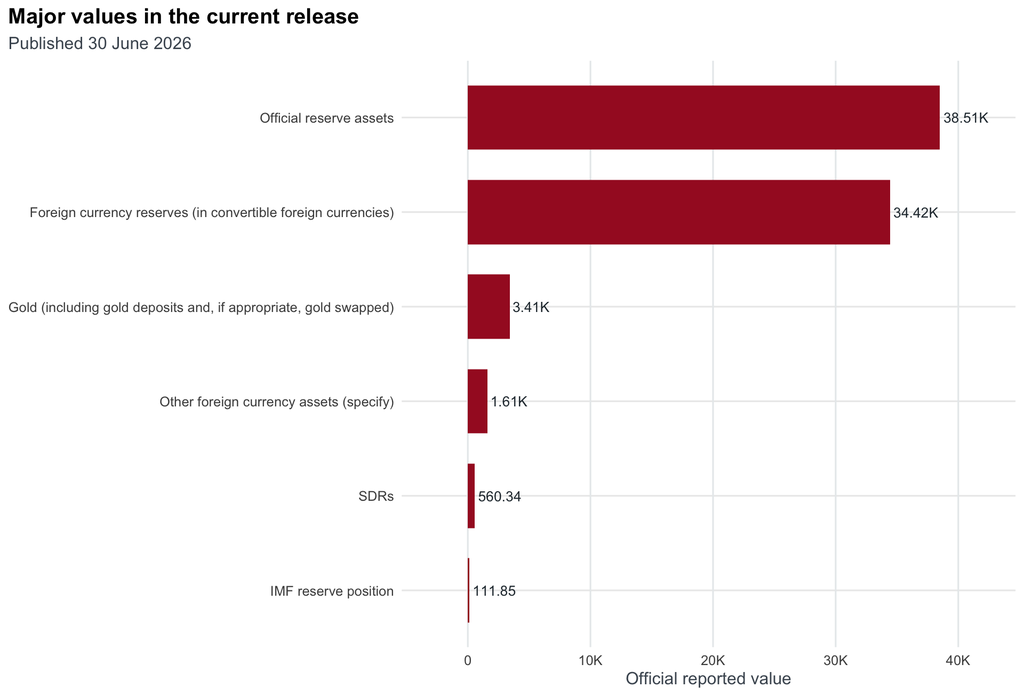

Latest values for the selected major series

| Series | Period | Value |
| --- | --- | --- |
| Foreign currency reserves (in convertible foreign currencies) | 2026-06 | 34,422.38 |
| Gold (including gold deposits and, if appropriate, gold swapped) | 2026-06 | 3,407.52 |
| IMF reserve position | 2026-06 | 111.85 |
| Official reserve assets | 2026-06 | 38,505.86 |
| Other foreign currency assets (specify) | 2026-06 | 1,605.36 |
| SDRs | 2026-06 | 560.34 |

## Rebuild the current values

Render the included data snapshot:

```r
rmarkdown::render(
  "inst/examples/pboc-current-series-dashboard.Rmd"
)
```

Refresh the current official catalog, download every latest workbook, normalise the reported values, and render:

```r
rmarkdown::render(
  "inst/examples/pboc-current-series-dashboard.Rmd",
  params = list(refresh_data = TRUE)
)
```

The refresh workflow uses these public package functions:

```r
current_year <- max(pboc_years("both")$year)
catalog <- pboc_catalog(
  current_year,
  language = "zh",
  formats = c("xlsx", "xls")
)
values <- pboc_read(catalog[1, ], sheet = NA, tidy = TRUE)
```